# Framework for Evaluating Damages & Impacts (FrEDI) - Example Run

U.S. Environmental Protection Agency

last updated: 22 March, 2023

# About This Document

This file provides an example analysis using EPA’s Framework for Evaluating Damages and Impacts (FrEDI).

**Overview:**

[figure not shown]

The [Framework for Evaluating Damages and Impacts (`FrEDI`)](https://www.epa.gov/cira/fredi) is a reduced complexity model that projects future impacts of climate change within the United States, under any custom temperature or policy pathway. This Framework draws upon existing peer-reviewed studies and climate change impact models, including from the EPA [Climate Change Impacts and Risk Analysis (CIRA)](https://www.epa.gov/cira) project, to estimate the relationship between future degrees of warming and sectoral impacts. When supplied with a user-defined future temperature trajectory, `FrEDI` then uses these temperature-impact relationships to rapidly estimate a projection of annual climate change impacts and damages through the end of the 21st century within the United States. FrEDI complements traditional scenario-based approaches to estimating climate change impacts by increasing the comparability between studies, flexibility to facilitate scenario analysis, and improving the communication of the breadth of physical and economic climate impacts.

**This example script:**

1. Installs the `FrEDI` R package from GitHub
2. Sets `FrEDI` input and run parameters.
3. Runs `FrEDI` with inputs specified in Step 2
4. Displays example plots of temperature trajectory and barchart of total annual U.S. climate-driven damages across impact categories.

For more information about `FrEDI`, visit: https://www.epa.gov/cira/fredi

Code available at: https://github.com/USEPA/FrEDI

#### **Disclaimer: This code is meant to provide an illustrative example of how to set-up, run, and process a subset of `FrEDI` output. The results and code in this file should not be used for further analysis.**

# Analysis Steps (Main `FrEDI`):

## Step 0. Install required R packages

Use this chunk to specify the required R libraries and set working directory (if needed)

```r
library("devtools")
library('knitr')
library('kableExtra')
```

## Step 1. Install `FrEDI` R package

Use this chunk to flag whether or not to install the `FrEDI` R package from [EPA’s Enterprise GitHub](https://github.com/USEPA/FrEDI). Users can also specify the branch to be installed. The default branch is set to `"main"`

```r
# NOTE: If the supporting R packages are not already installed on your computer,
# it will take a few minutes (up to a few hours) the first time you load the FrEDI package.

# Specify if you want to install the FrEDI package (install = TRUE, Don't install = FALSE)
# If already installed, set to FALSE
inst_flag = FALSE

# Specify branch
# The user can also load a different branch or tagged release
branch = 'main'


if ( inst_flag == TRUE){
  withr::with_libpaths(
    new = .libPaths()[1],
    devtools::install_github(
      repo = "USEPA/FrEDI",
      subdir = "FrEDI",
      type = "source",
      force = TRUE,
      ref = branch
    ))
  library("FrEDI")
} else {
  require("FrEDI")
}
```

## Step 2. Set `FrEDI` Runtime parameters

Use this chunk to specify the input trajectories (temperature, population, GDP) and runtime parameters for `FrEDI`.

```r
# Set FrEDI inputs and parameters

# 1. Select input trajectories
# 1a. Select from one of the pre-processed global temperature trajectories

# NOTE: these were processed using the FaIR model v1.6.4 (https://github.com/OMS-NetZero/FAIR)

# Pre-processed SSPs (select one by un-commenting)
  #temp_file = 'SSP119_globaltemp_4FrEDI.csv'
  #temp_file = 'SSP126_globaltemp_4FrEDI.csv'
  temp_file = 'SSP245_globaltemp_4FrEDI.csv'
  #temp_file = 'SSP370_globaltemp_4FrEDI.csv'
  #temp_file = 'SSP370_lowNTCF_globaltemp_4FrEDI.csv'
  #temp_file = 'SSP434_globaltemp_4FrEDI.csv'
  #temp_file = 'SSP460_globaltemp_4FrEDI.csv'
  #temp_file = 'SSP534_globaltemp_4FrEDI.csv'
  #temp_file = 'SSP585_globaltemp_4FrEDI.csv'
  #specify path
  temp_file_loc = paste0(getwd(),"/SSPs_for_FrEDI/",temp_file)

# To run more than one scenario, the code below must be
# adapted into a loop to format the inputs for each scenario.

#***********************************************
#1b. Specify & Format Other Input Files

## Input Files
tempInputFile <- temp_file_loc
  # Description: csv file with time series of temperature relative to 1986-2005 average
  # (units: degC, values: >=0)
  # data must start in 2000 or earlier and can be global or CONUS
  # If global --> must convert to CONUS temperature using the import_inputs() helper function
  # column 1 = 'year', column 2 = 'temp_C'

slrInputFile <- NULL
  # Description: csv file with time series of global mean sea level rise relative to 2000
  # (units: cm, values: >= 0 and <= 250)
  # data must start in 2000 or earlier
  # column 1 = 'year', column 2 = 'slr_cm'
  # If NULL - slr is calculated from the input temperature trajectory

gdpInputFile <- NULL
  # Description: csv file with time series of Gross Domestic Product (units: 2015$, values: >= 0)
  # data must start in 2000 or earlier
  # column 1 = 'year', column 2 = 'gdp_usd'
  # If NULL - use default GDP trajectory

popInputFile <- NULL
  # Description: csv file with time series of annual NCA regional population (values >= 0)
  # data must start in 2000 or earlier
  # column 1 = 'year', columns 2:x = depends on data format (popform)
  # If NULL - use default population trajectory (from ICLUS)


## Input Trajectory parameters
popformFlag = 'wide'
  # Description: Use this to specify the format of the regional population data
  # Options: wide/long.
  # Wide = columns 2-8 correspond to population in each NCA region.
  # Long = column 2 = NCA region name ('region'),
  # column 3 = population for that region ('reg_pop').
  # NCA region names: 'Midwest', 'Northeast', 'Northern.Plains', 'Northwest',
  #   'Southeast', 'Southern.Plains', 'Southwest'

temptypeflag <- 'global'
  # Description: Use this to specify whether the input temperature is global or CONUS
  # import_inputs() will convert to global to CONUS temperature
  # Options: global (input is global T), conus (input is CONUS T)

## Use the import_inputs() helper function to format the input trajectories for use in FrEDI
inputs_list <- import_inputs(tempfile = tempInputFile,
                        slrfile = slrInputFile,
                        popfile = popInputFile,
                        gdpfile = gdpInputFile,
                        temptype = temptypeflag,
                        popform = popformFlag)

# print out how many custom input files were loaded
# should be = 1 if using custom temperature only
if ( length(inputs_list) ==0 ){
  print('CHECK FILE LOCATIONS: No input Data Loaded')
} else {
  print( paste('Number of input files loaded:',length(inputs_list)))
}

#*******************************
# 2. Set FrEDI Run Parameters (NULL = default)

thru2300Flag = FALSE
  # Purpose:
  #   Specify whether to run FrEDI through 2100 (default) or extend to 2300
  # Default: FALSE (will run to 2100)

baseYearFlag <- NULL
  # Purpose:
  #   Specify base year for calculating present values of annual impacts
  # Default: 2010

SectorListFlag <- NULL
  # Purpose:
  #   Specify the vector of sectors to calculate results for
  # Default: report output for all sectors
  # See FrEDI:get_sectorInfo() for list of all sectors

aggLevelFlag <- NULL
  # Purpose:
  #   Specify the desired level of results aggregation. For example,
  #   to report national total results across all underlying climate-model
  #   damage functions, set the flag to c('national','modelaverage')
  # Options: at least one from c('national', 'modelaverage', 'impactyear',
  #   'impacttype', 'all'), or "none".
  # Default: c('national', 'modelaverage', 'impactyear','impacttype')

pvFlag <- NULL
  # Purpose:
  #   Calculate the present value of annual monetized impacts
  # Options: TRUE/FALSE.
  # Default: FALSE

rateFlag <- NULL
  # Purpose:
  #   If pvFlag = TRUE, specify the annual constant discount rate used
  #   to calculate present values
  # Default: 0.03

elasticityFlag <- 1
  # Purpose:
  #   Specify the income elasticity used to adjust the Value of a
  #   Statistical Life (VSL)
  # Options: any numeric value
  # Default:


silentFlag <- NULL
  # Purpose:
  #   Specify the level of messaging to the user
  # Options: TRUE/FALSE.
  # Default: TRUE


#**********************************************
```

```
## [1] "Number of input files loaded: 1"
```

## Step 3. Run FrEDI

Run `FrEDI` using the main `run_fredi()` function

```r
#Run FrEDI using inputs and parameters set in Step #2

output_df <- run_fredi(inputsList= inputs_list,
                       thru2300 = thru2300Flag,
                       sectorList = SectorListFlag,
                       aggLevels=aggLevelFlag,
                       pv = pvFlag,
                       baseYear = baseYearFlag,
                       rate = rateFlag,
                       elasticity = elasticityFlag,
                       silent = silentFlag
                       )

# Option: write output
## Write Full Dataframe to CSV (or feather)
# write.csv(output_df, './output/example_output.csv')
```

## Step 4. Plot

The following chunks provide examples of figures generated from `FrEDI` data

### Define plotting parameters

Use this chunk to define sector categories and global plotting parameters

```r
#Define plotting parameters

# Define aggregate categories
# Sample sector aggregations similar to Hartin et al., 2023
# NOTE: the health category can include 1 of the following:
#  'Extreme Temperature'
#  'ATS Extreme Temperature'
#  'CIL Extreme Temperature'
health_cat <- c("ATS Extreme Temperature","Air Quality",
                "Valley Fever","Wildfire","Southwest Dust",
                "CIL Crime")
labor_cat  <- c("Labor")
agr_cat    <- c("CIL Agriculture")
elect_cat  <- c("Electricity Demand and Supply",
                "Electricity Transmission and Distribution")
infra_cat  <- c("Rail","Roads","Urban Drainage",
                "Coastal Properties",
                "High Tide Flooding and Traffic", "Inland Flooding",
                "Wind Damage")
eco_cat    <- c("Marine Fisheries", "Winter Recreation",
                "Water Quality")


#Example color palette
colors_6 = c("#f2938c", "#d54309", "#ffbc78", "#4d8055", "#97d4ea", "#1a4480")
```

### Plot Temperature Trajectory

Plot a time series of the input U.S. temperature trajectory in units of degrees C, relative to 1986-2005 average baseline

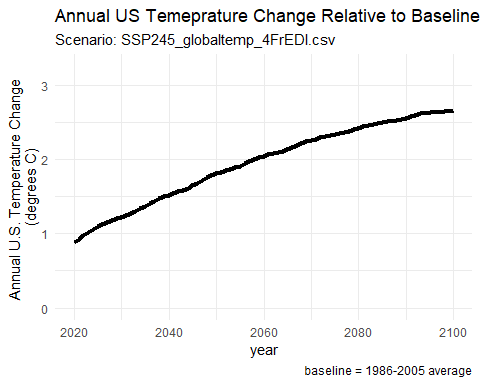

```r
# take formatted temperature vector from the output of the import_inputs() helper function
temp_C <- inputs_list$tempInput

# plot line graph
p_temp <- temp_C %>%
  ggplot(aes(x=year,
             y=temp_C)) +
  geom_line(linewidth=1.5,
            na.rm = TRUE) +
  xlim(2020,2100)+
  ylab('Annual U.S. Temperature Change \n(degrees C)') +
  theme(legend.position = 'none')+
  theme_minimal()+
  labs(title="Annual US Temeprature Change Relative to Baseline",
       subtitle= paste0("Scenario: ",temp_file),
       caption='baseline = 1986-2005 average')


p_temp
```

### Plot National Results by Category

Plot a bar chart of annual national total damages for select years, colored by aggregate sector categories

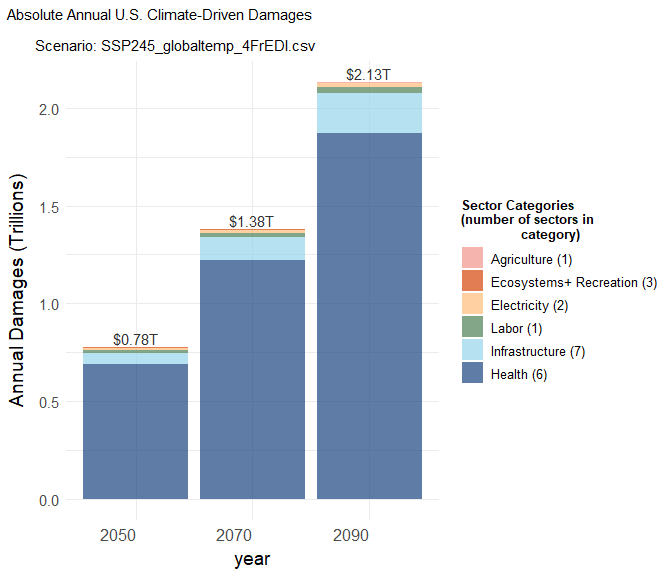

```r
#specify years to plot
c_years = c(2050, 2070, 2090)

#filter and aggregate data, assign to aggregate categories
df_filter <- output_df %>%
  # filter for primary sectors and variants (included to avoid double counting)
    filter(sectorprimary ==1) %>%
  # filter for national aggregate results
    filter(model %in% c('Average','Interpolation'),
           region == "National Total",
           year %in% c_years) %>%
  #convert dollars to trillions of dollars
    mutate(annual_impacts = annual_impacts /1e12) %>%
    mutate(year = as.factor(year)) %>%
  #assign sectors to categories
    mutate(category = case_when(
    sector %in% labor_cat ~ "Labor (1)",
    sector %in% agr_cat ~ "Agriculture (1)",
    sector %in% elect_cat ~ "Electricity (2)",
    sector %in% health_cat ~ "Health (6)",
    sector %in% infra_cat ~ "Infrastructure (7)",
    sector %in% eco_cat ~ "Ecosystems+ Recreation (3)",
    TRUE ~ NA_character_)) %>%
    filter(category != "NA")


#reorder from largest to smallest category
cat_i <- df_filter %>%
  group_by_at(.vars=c("category")) %>%
  summarize_at(.vars=c("annual_impacts"),sum,na.rm=T) %>%
  ungroup %>%
  arrange_at(.vars=c("annual_impacts", "category"))

df_filter <- df_filter %>%
  mutate(category = category %>%
           factor(levels = (cat_i$category))) %>%
  arrange_at(.vars=c("category"))


# plot bar chart
p_national_damages <- df_filter %>%
  ggplot() +
  geom_bar(aes(fill=category,
               y=annual_impacts,
               x=year),
           position="stack",
           stat="identity",
           alpha = 0.7) +
  scale_y_continuous("Annual Damages (Trillions)")+
  scale_fill_manual(values=(colors_6))+
  theme_minimal() +
  theme(axis.text = element_text(size=11),
        axis.title = element_text(size =14),
        axis.title.y = element_text(margin =
                            margin(t = 0,r = 10,b = 0,l = 0)),
        axis.title.x = element_text(margin =
                            margin(t = 5,r = 0,b = 0,l = 0)),
        legend.text=element_text(size=10),
        legend.title=element_text(size=10,
                                  face="bold"),
        plot.title = element_text(size = 16,
                                  face = "bold"),
        plot.title.position = "plot",
        axis.text.x = element_text(vjust = 1,
                                   hjust=1,
                                   angle = 0,
                                   size=12),
        legend.position = 'right')+
  labs(subtitle=paste0("Absolute Annual U.S. Climate-Driven Damages\n
       Scenario: ",temp_file),
       fill = "Sector Categories \n(number of sectors in
               category)")+
  #add value to plot
  geom_text(data=df_filter %>%
            group_by_at(.vars=c("year")) %>%
            summarize_at(.vars = c("annual_impacts"),sum,na.rm=T),
            aes(x=year,
                y=annual_impacts,
                label=paste0('$', round(annual_impacts, 2),'T'),
                vjust=-0.25),
            color    = 'grey20',
            size     = 4)

#plot figure
p_national_damages
```

### Table of National Sectoral Results (billions $2015USD)

Print table of total annual national damages, by sector, for a specific year

```r
#choose year to plot
c_year = 2090

#Table 1
df_filter <- output_df %>%
  # filter for primary sectors and variants (included to avoid double counting)
    filter(sectorprimary ==1) %>%
  # filter for national aggregate results
    filter(model %in% c('Average','Interpolation'),
           region == "National Total",
           year == c_year) %>%
  #convert $ to billions $
    mutate(annual_impacts = annual_impacts /1e9) %>%
  #assign sectors to category
    mutate(category = case_when(
    sector %in% labor_cat ~ "Labor (1)",
    sector %in% agr_cat ~ "Agriculture (1)",
    sector %in% elect_cat ~ "Electricity (2)",
    sector %in% health_cat ~ "Health (6)",
    sector %in% infra_cat ~ "Infrastructure (7)",
    sector %in% eco_cat ~ "Ecosystems+ Recreation (3)",
    TRUE ~ NA_character_)) %>%
    filter(category != "NA") %>%
  #select relevant columns and re-order
    select('sector','category','annual_impacts','region','year') %>%
    arrange(desc(annual_impacts)) %>%
    mutate(across(c('annual_impacts'), ~ signif(.,2)))


# print National Total Damages by Sector (in billions of $ in $2015USD)
#print(table1)
colnames(df_filter) <- c('Sector','Category','Billons (2015 $ USD)','Region','Year')
kable(df_filter, caption = paste0('National Total Damages by Sector, Scenario: ',temp_file)) %>%
  kable_styling(font_size = 12, full_width = F)
```

National Total Damages by Sector, Scenario: SSP245_globaltemp_4FrEDI.csv

| Sector | Category | Billons (2015 $ USD) | Region | Year |
| --- | --- | --- | --- | --- |
| ATS Extreme Temperature | Health (6) | 1700.000 | National Total | 2090 |
| Air Quality | Health (6) | 160.000 | National Total | 2090 |
| High Tide Flooding and Traffic | Infrastructure (7) | 130.000 | National Total | 2090 |
| Wildfire | Health (6) | 37.000 | National Total | 2090 |
| Labor | Labor (1) | 31.000 | National Total | 2090 |
| Wind Damage | Infrastructure (7) | 26.000 | National Total | 2090 |
| Rail | Infrastructure (7) | 17.000 | National Total | 2090 |
| Roads | Infrastructure (7) | 15.000 | National Total | 2090 |
| Southwest Dust | Health (6) | 13.000 | National Total | 2090 |
| Electricity Demand and Supply | Electricity (2) | 11.000 | National Total | 2090 |
| Electricity Transmission and Distribution | Electricity (2) | 10.000 | National Total | 2090 |
| Valley Fever | Health (6) | 10.000 | National Total | 2090 |
| Coastal Properties | Infrastructure (7) | 7.300 | National Total | 2090 |
| CIL Agriculture | Agriculture (1) | 4.400 | National Total | 2090 |
| Urban Drainage | Infrastructure (7) | 4.100 | National Total | 2090 |
| Water Quality | Ecosystems+ Recreation (3) | 2.200 | National Total | 2090 |
| Winter Recreation | Ecosystems+ Recreation (3) | 2.100 | National Total | 2090 |
| CIL Crime | Health (6) | 0.890 | National Total | 2090 |
| Inland Flooding | Infrastructure (7) | 0.710 | National Total | 2090 |
| Marine Fisheries | Ecosystems+ Recreation (3) | -0.057 | National Total | 2090 |

# `FrEDI` SV Module

NOTE: ‘main’ run_fredi_sv does not currently run. (‘sv_template_update’ branch has the latest version)